# White Wine Quality Analysis by Mehdi Jafari

This data set contains 4898 white wines with 11 variables on the chemical properties of the wine. At least 3 wine experts rated the quality of each wine,  
providing a rating between 0 (very bad) and 10 (very excellent).

# Univariate Plots Section

```
## 'data.frame':    4898 obs. of  12 variables:
##  $ fixed.acidity       : num  7 6.3 8.1 7.2 7.2 8.1 6.2 7 6.3 8.1 ...
##  $ volatile.acidity    : num  0.27 0.3 0.28 0.23 0.23 0.28 0.32 0.27 0.3 0.22 ...
##  $ citric.acid         : num  0.36 0.34 0.4 0.32 0.32 0.4 0.16 0.36 0.34 0.43 ...
##  $ residual.sugar      : num  20.7 1.6 6.9 8.5 8.5 6.9 7 20.7 1.6 1.5 ...
##  $ chlorides           : num  0.045 0.049 0.05 0.058 0.058 0.05 0.045 0.045 0.049 0.044 ...
##  $ free.sulfur.dioxide : num  45 14 30 47 47 30 30 45 14 28 ...
##  $ total.sulfur.dioxide: num  170 132 97 186 186 97 136 170 132 129 ...
##  $ density             : num  1.001 0.994 0.995 0.996 0.996 ...
##  $ pH                  : num  3 3.3 3.26 3.19 3.19 3.26 3.18 3 3.3 3.22 ...
##  $ sulphates           : num  0.45 0.49 0.44 0.4 0.4 0.44 0.47 0.45 0.49 0.45 ...
##  $ alcohol             : num  8.8 9.5 10.1 9.9 9.9 10.1 9.6 8.8 9.5 11 ...
##  $ quality             : int  6 6 6 6 6 6 6 6 6 6 ...
```

```
##  fixed.acidity    volatile.acidity  citric.acid     residual.sugar
##  Min.   : 3.800   Min.   :0.0800   Min.   :0.0000   Min.   : 0.600
##  1st Qu.: 6.300   1st Qu.:0.2100   1st Qu.:0.2700   1st Qu.: 1.700
##  Median : 6.800   Median :0.2600   Median :0.3200   Median : 5.200
##  Mean   : 6.855   Mean   :0.2782   Mean   :0.3342   Mean   : 6.391
##  3rd Qu.: 7.300   3rd Qu.:0.3200   3rd Qu.:0.3900   3rd Qu.: 9.900
##  Max.   :14.200   Max.   :1.1000   Max.   :1.6600   Max.   :65.800
##    chlorides       free.sulfur.dioxide total.sulfur.dioxide
##  Min.   :0.00900   Min.   :  2.00      Min.   :  9.0
##  1st Qu.:0.03600   1st Qu.: 23.00      1st Qu.:108.0
##  Median :0.04300   Median : 34.00      Median :134.0
##  Mean   :0.04577   Mean   : 35.31      Mean   :138.4
##  3rd Qu.:0.05000   3rd Qu.: 46.00      3rd Qu.:167.0
##  Max.   :0.34600   Max.   :289.00      Max.   :440.0
##     density             pH          sulphates         alcohol
##  Min.   :0.9871   Min.   :2.720   Min.   :0.2200   Min.   : 8.00
##  1st Qu.:0.9917   1st Qu.:3.090   1st Qu.:0.4100   1st Qu.: 9.50
##  Median :0.9937   Median :3.180   Median :0.4700   Median :10.40
##  Mean   :0.9940   Mean   :3.188   Mean   :0.4898   Mean   :10.51
##  3rd Qu.:0.9961   3rd Qu.:3.280   3rd Qu.:0.5500   3rd Qu.:11.40
##  Max.   :1.0390   Max.   :3.820   Max.   :1.0800   Max.   :14.20
##     quality
##  Min.   :3.000
##  1st Qu.:5.000
##  Median :6.000
##  Mean   :5.878
##  3rd Qu.:6.000
##  Max.   :9.000
```

### Quality

We can see in the following diagram that the quality has a fairly normal distribution.

```
##    Min. 1st Qu.  Median    Mean 3rd Qu.    Max.
##   3.000   5.000   6.000   5.878   6.000   9.000
```

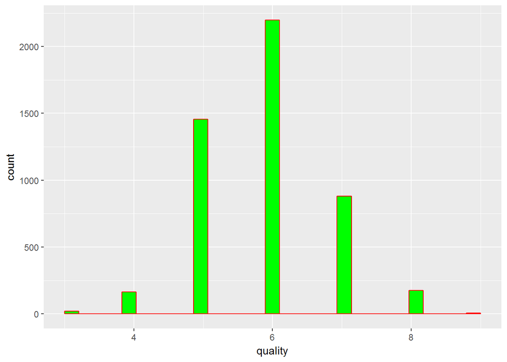

### Fixed Acidity

The distribution of fixed acidity is normal, 50 percent of the observations have between 6.300 to 7.300 g/dm^3 tartaric acid.

```
##    Min. 1st Qu.  Median    Mean 3rd Qu.    Max.
##   3.800   6.300   6.800   6.855   7.300  14.200
```

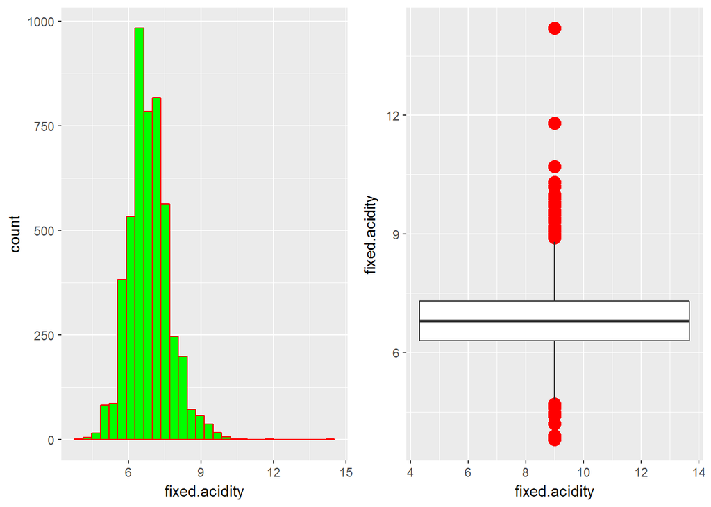

### Volatile Acidity

The amount of acetic acid in wine, which at too high of levels can lead to an unpleasant, vinegar taste. This variable seems to have many outliers as the mean is 0.2782 and the maximum value in the distribution is 1.1.

```
##    Min. 1st Qu.  Median    Mean 3rd Qu.    Max.
##  0.0800  0.2100  0.2600  0.2782  0.3200  1.1000
```

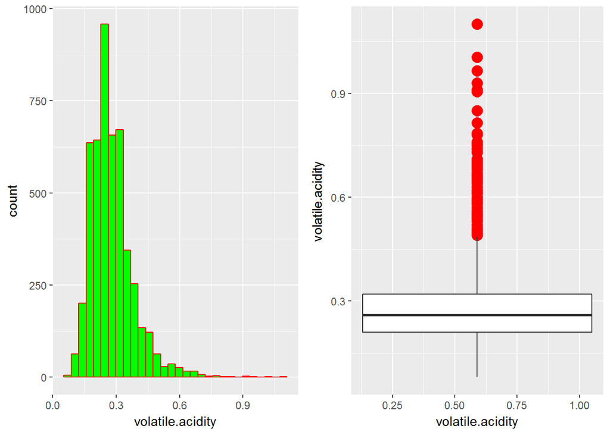

### Citric Acid

Citric Acid is found in small quantities, citric acid can add ‘freshness’ and flavor to wines. 75 percent of observations have less than 0.3900 g/dm^3 citric.acid while the max is 1.66 mg.

```
##    Min. 1st Qu.  Median    Mean 3rd Qu.    Max.
##  0.0000  0.2700  0.3200  0.3342  0.3900  1.6600
```

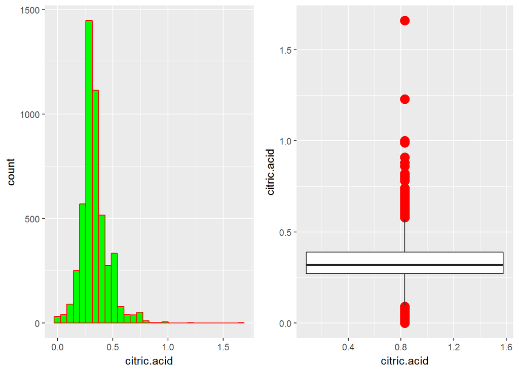

### Residual Sugar

```
##    Min. 1st Qu.  Median    Mean 3rd Qu.    Max.
##   0.600   1.700   5.200   6.391   9.900  65.800
```

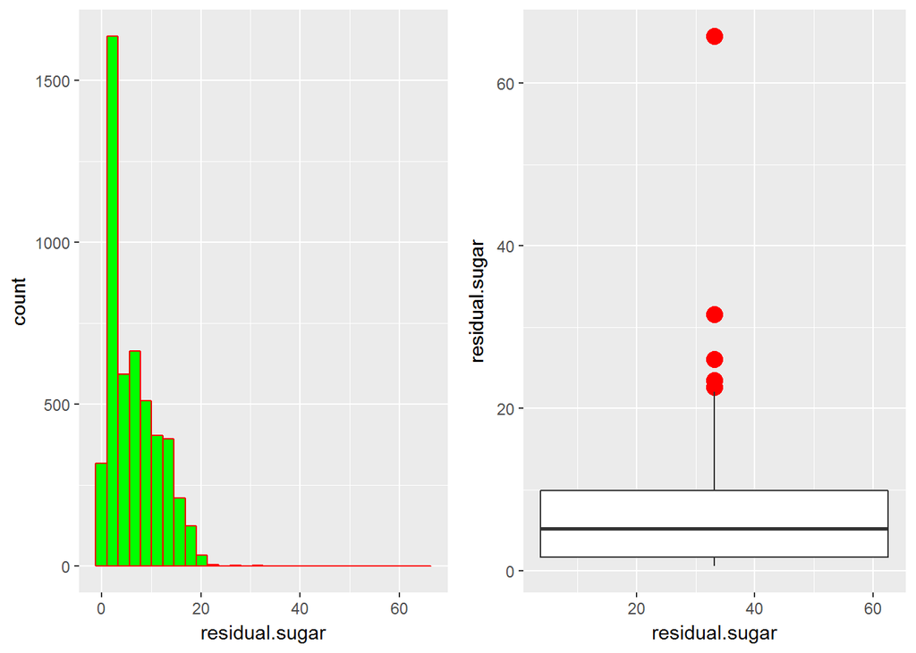

### Chlorides

Chlorides is the amount of salt in the wine. As it’s depicted in the following plot, it has right skewed distribution.

```
##    Min. 1st Qu.  Median    Mean 3rd Qu.    Max.
## 0.00900 0.03600 0.04300 0.04577 0.05000 0.34600
```

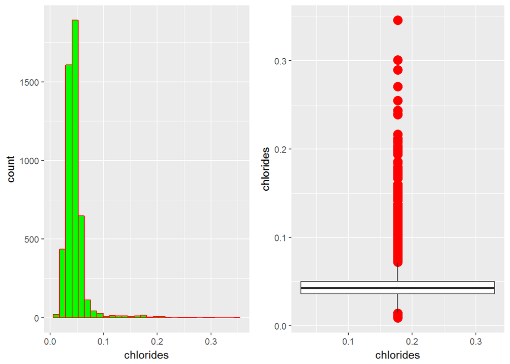

### Free Sulfur Dioxide

The free form of SO2 exists in equilibrium between molecular SO2 (as a dissolved gas) and bisulfite ion; it prevents microbial growth and the oxidation of wine.

```
##    Min. 1st Qu.  Median    Mean 3rd Qu.    Max.
##    2.00   23.00   34.00   35.31   46.00  289.00
```

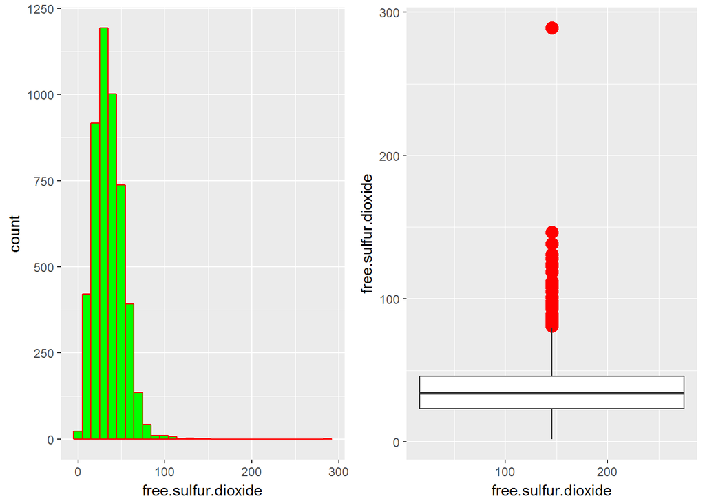

### Total Sulfur Dioxide

```
##    Min. 1st Qu.  Median    Mean 3rd Qu.    Max.
##     9.0   108.0   134.0   138.4   167.0   440.0
```

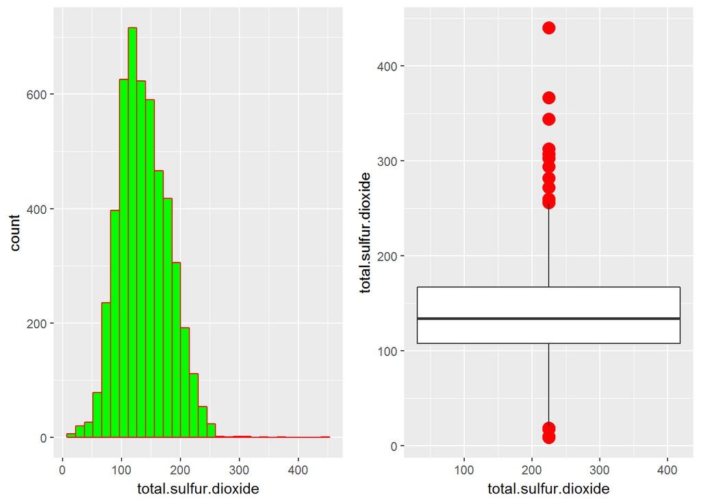

### Density

The density of water is close to that of water depending on the percent alcohol and sugar content. This variable has only 3 outliers in our dataset.

```
##    Min. 1st Qu.  Median    Mean 3rd Qu.    Max.
##  0.9871  0.9917  0.9937  0.9940  0.9961  1.0390
```

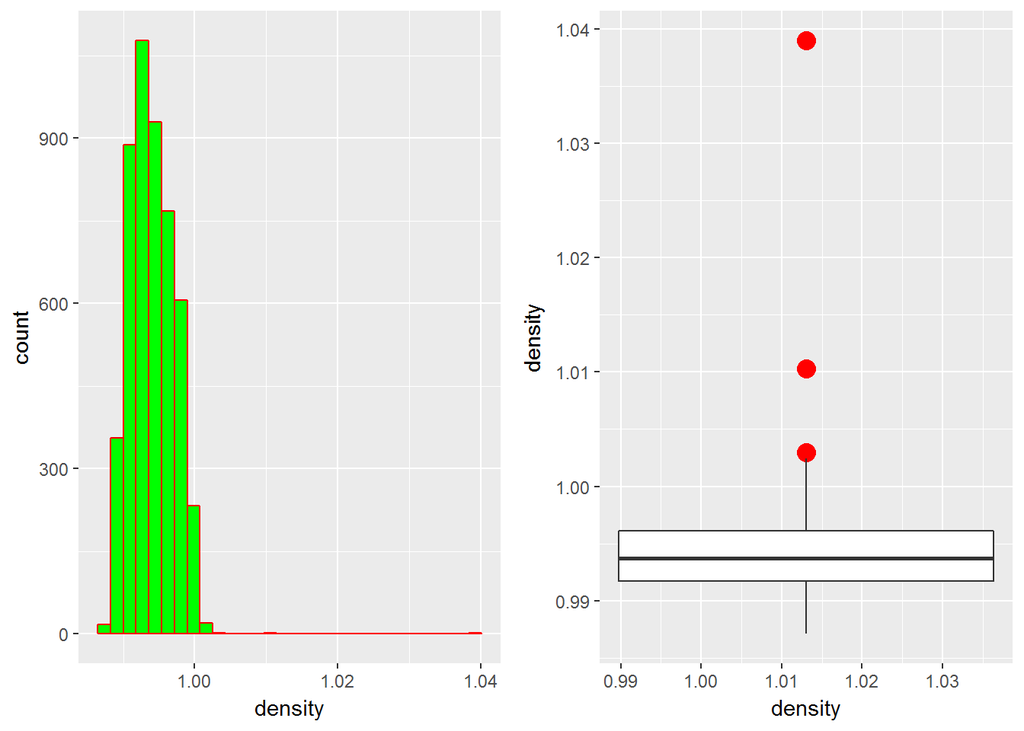

### PH

Describes how acidic or basic a wine is on a scale from 0 (very acidic) to 14 (very basic); most wines are between 3-4 on the pH scale.

```
##    Min. 1st Qu.  Median    Mean 3rd Qu.    Max.
##   2.720   3.090   3.180   3.188   3.280   3.820
```

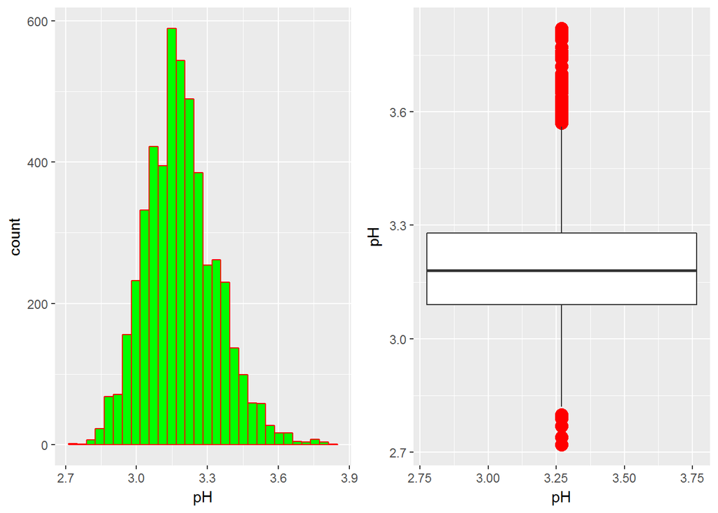

### Sulphates

A wine additive which can contribute to sulfur dioxide gas (S02) levels, which acts as an antimicrobial and antioxidant.

```
##    Min. 1st Qu.  Median    Mean 3rd Qu.    Max.
##  0.2200  0.4100  0.4700  0.4898  0.5500  1.0800
```

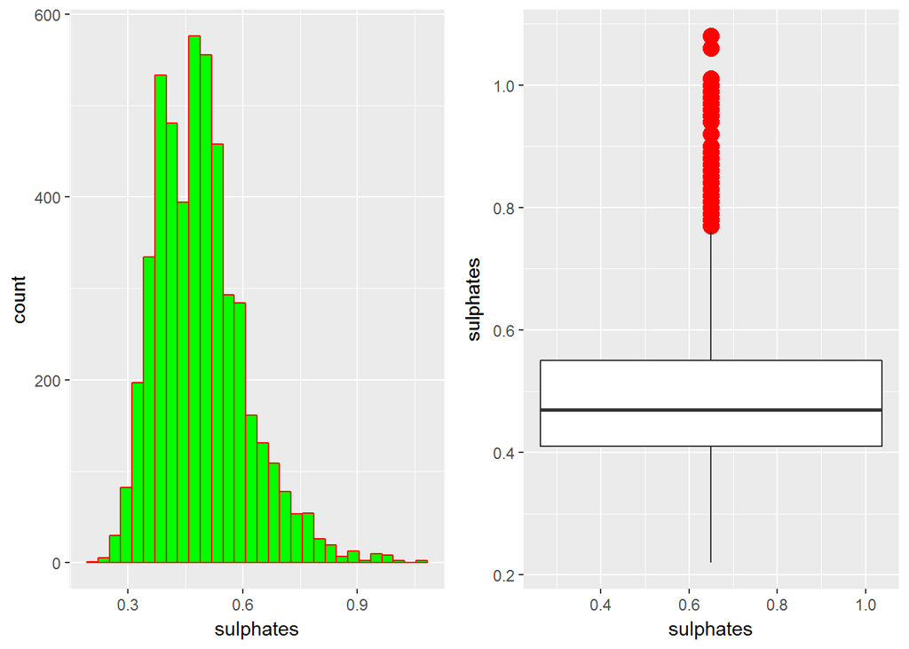

### Alcohol

The percent alcohol content of the wine. There is no outlier in alcohol distribution.

```
##    Min. 1st Qu.  Median    Mean 3rd Qu.    Max.
##    8.00    9.50   10.40   10.51   11.40   14.20
```

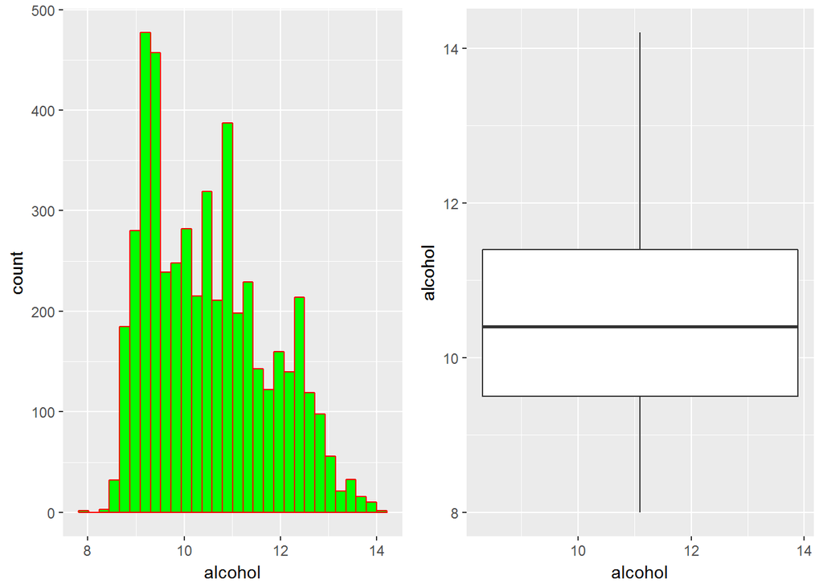

# Univariate Analysis

### What is/are the main feature(s) of interest in your dataset?

The main feature in our dataset is quality. In this report will try to find a correlation between other variables and quality.

### What other features in the dataset do you think will help support your into your feature(s) of interest?

residual sugar, volatile acidity, density and alcohol could have correlation with quality of wine.

### Did you create any new variables from existing variables in the dataset?

In order to have a better diagram, quality is categorized into four factors (bad (0-4), average (4-6), good (7-8) and excellent (9-10))

### Of the features you investigated, were there any unusual distributions?you perform any operations on the data to tidy, adjust, or change the formthe data? If so, why did you do this?

As it is mentioned earlier residual.sugar and chlorides have right skewed distribution then a log10 transformation is applied to these variables. the plots are depicted in the following:

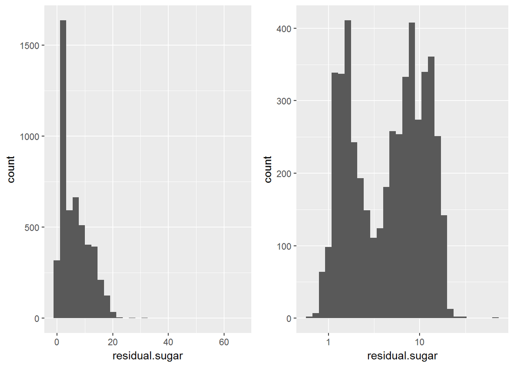

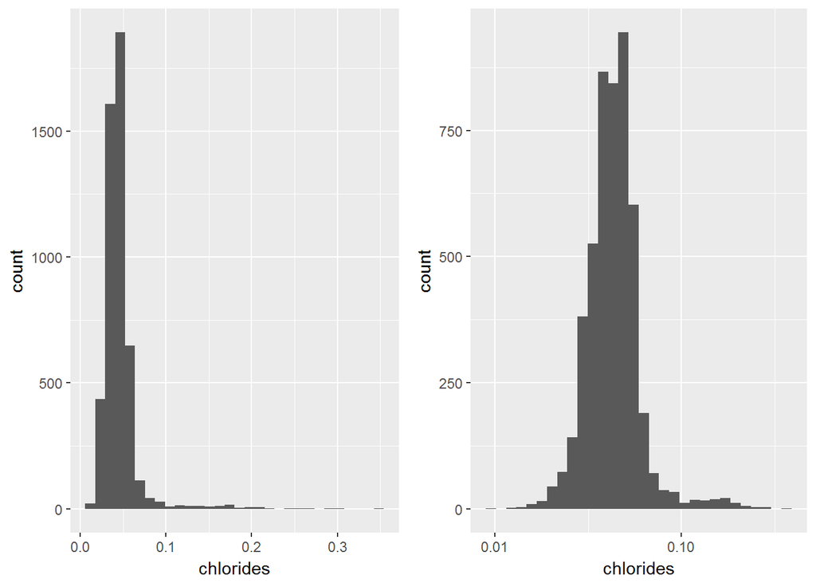

# Bivariate Plots Section

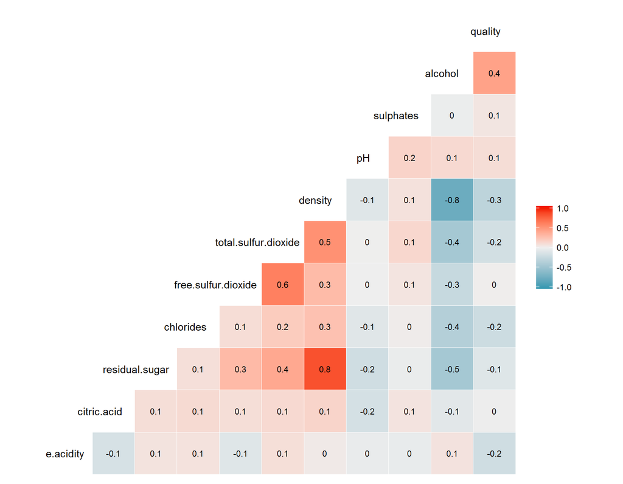

```
##                    Var1                 Var2     value
## 1      volatile.acidity     volatile.acidity 1.0000000
## 2           citric.acid          citric.acid 1.0000000
## 3        residual.sugar       residual.sugar 1.0000000
## 4             chlorides            chlorides 1.0000000
## 5   free.sulfur.dioxide  free.sulfur.dioxide 1.0000000
## 6  total.sulfur.dioxide total.sulfur.dioxide 1.0000000
## 7               density              density 1.0000000
## 8                    pH                   pH 1.0000000
## 9             sulphates            sulphates 1.0000000
## 10              alcohol              alcohol 1.0000000
## 11              quality              quality 1.0000000
## 12              density       residual.sugar 0.8389665
## 13       residual.sugar              density 0.8389665
## 14 total.sulfur.dioxide  free.sulfur.dioxide 0.6155010
## 15  free.sulfur.dioxide total.sulfur.dioxide 0.6155010
## 16              density total.sulfur.dioxide 0.5298813
## 17 total.sulfur.dioxide              density 0.5298813
```

[output not shown]

As it is shown in the above mentioned result, the following pairs have the most correlation with each other:

- density and residual.sugar
- total.sulfur.dioxide and free.sulfur.dioxide
- density and total.sulfur.dioxide

since free.sulfur.dioxide is a subset of total.sulfur.dioxide, we will not investigate those pairs.

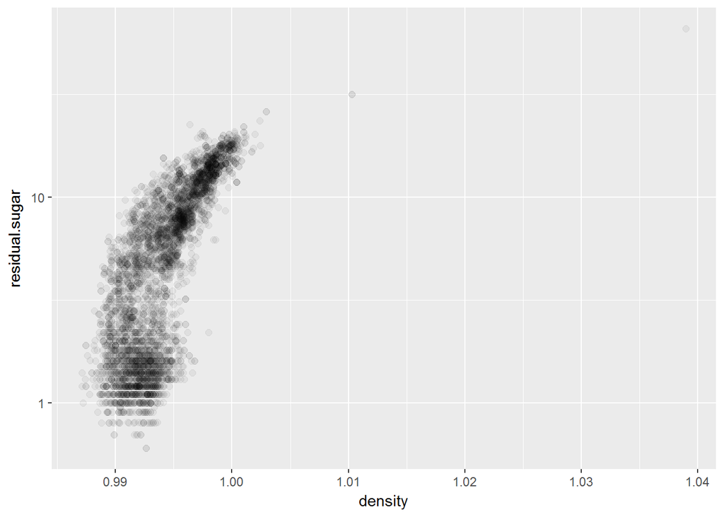

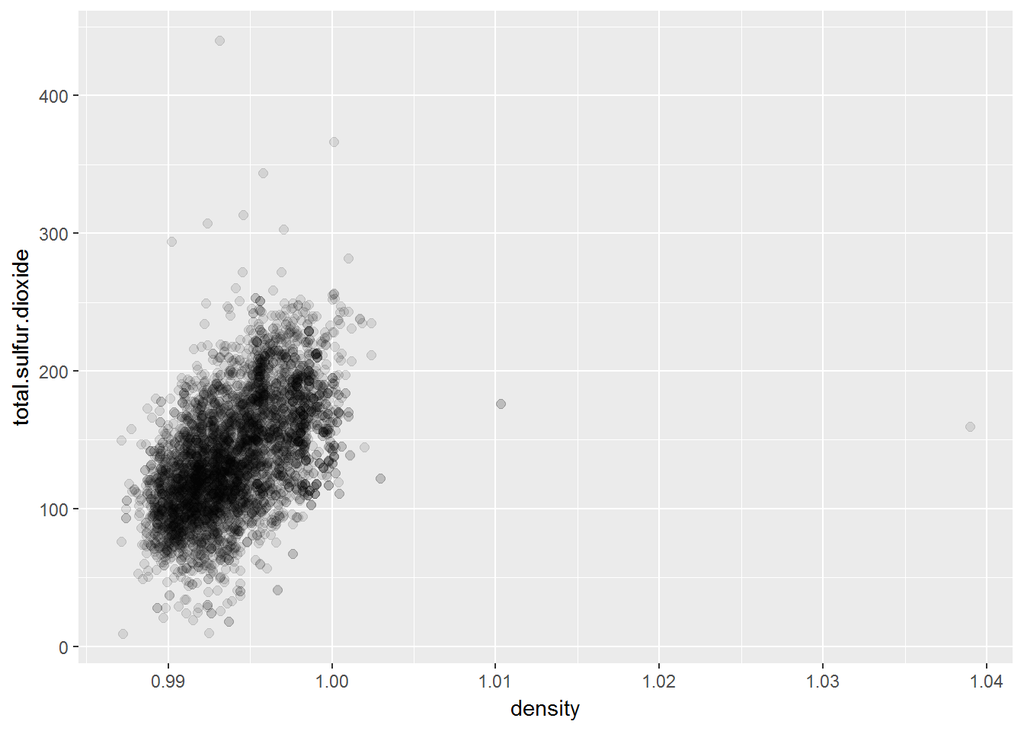

Since the alcohol has the greatest correlation with quality which is the main factor, plot the correlation of these two variable could be helpful.

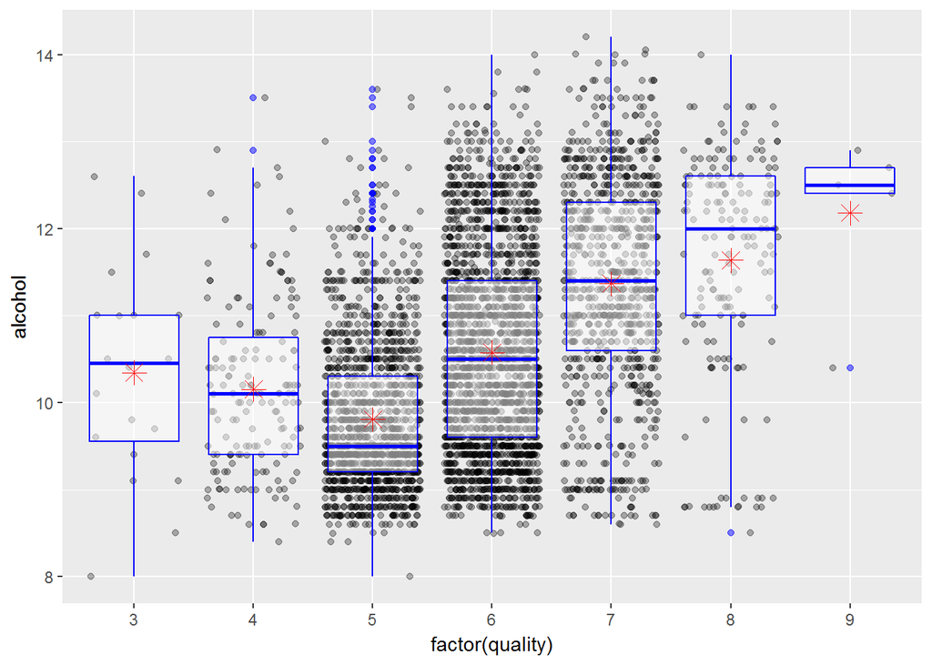

# Bivariate Analysis

### Talk about some of the relationships you observed in this part of the

investigation. How did the feature(s) of interest vary with other features in

the dataset?

Based on the result we may say that alcohol has the most correlation with the quality (0.4355747) and has the least correlation with citiric.acid (0.009209091).

### Did you observe any interesting relationships between the other features

(not the main feature(s) of interest)?

As it is represented in the two previous plots, the more residual.sugar and total.sulfur.dioxide, the more density.

### What was the strongest relationship you found?

As it was mentioned the strongest relationship is between density and residual.sugar which is 0.8389665

# Multivariate Plots Section

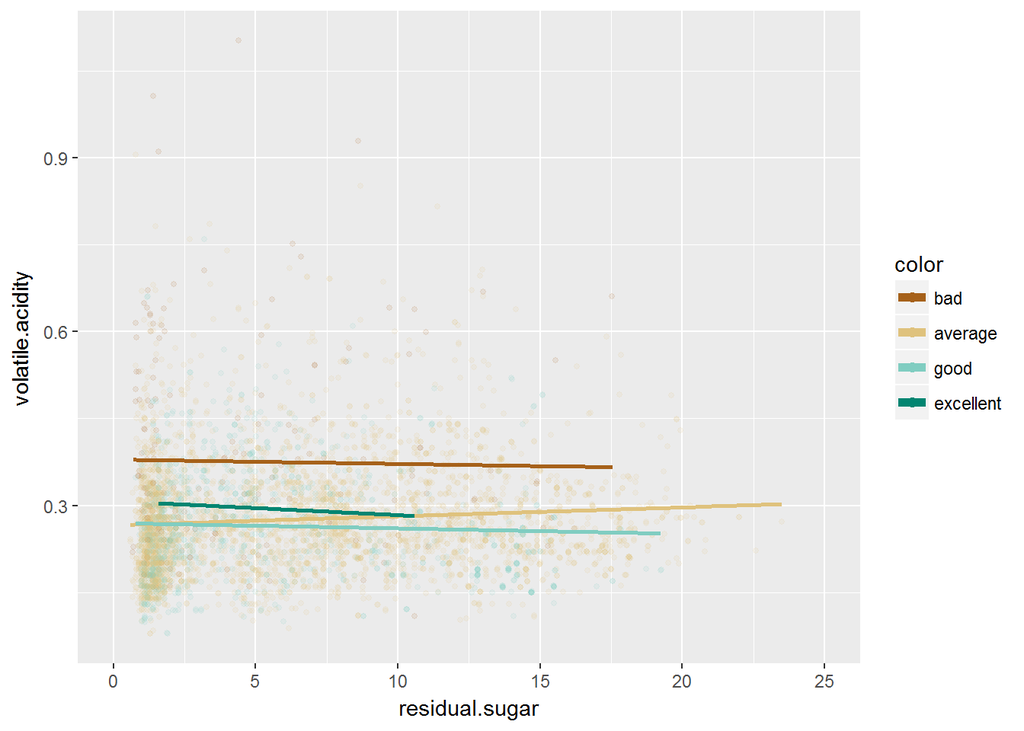

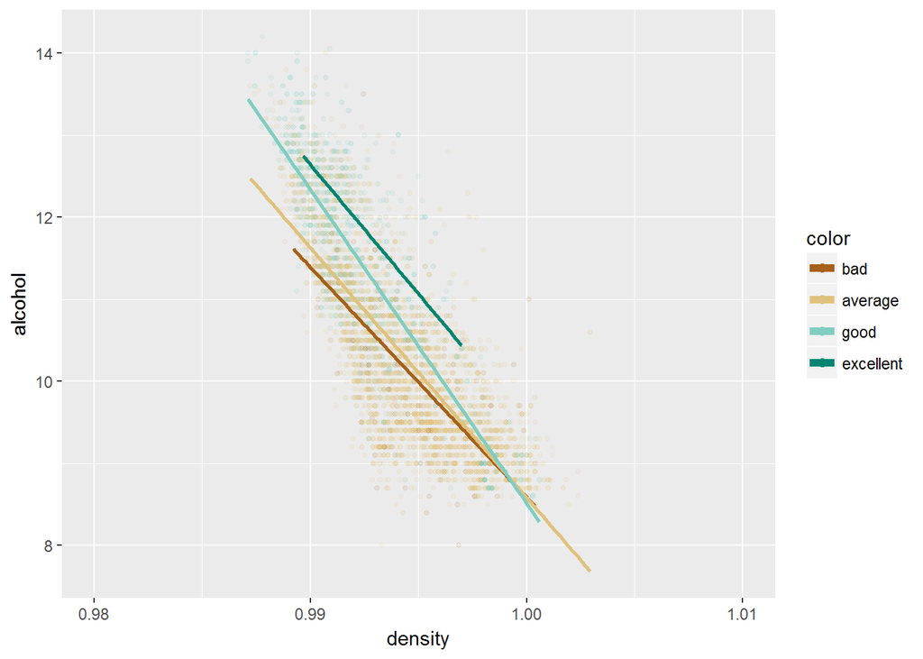

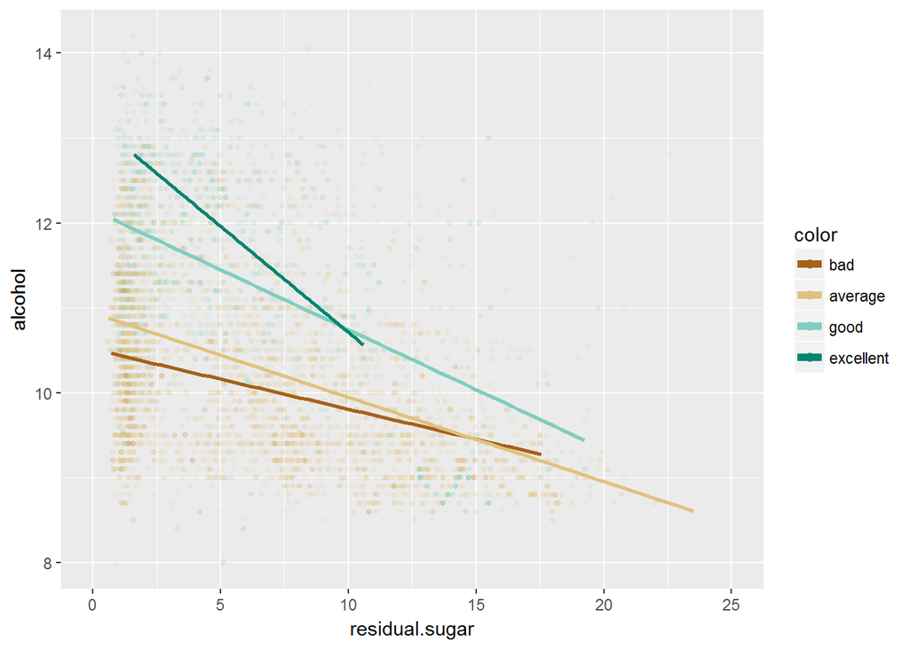

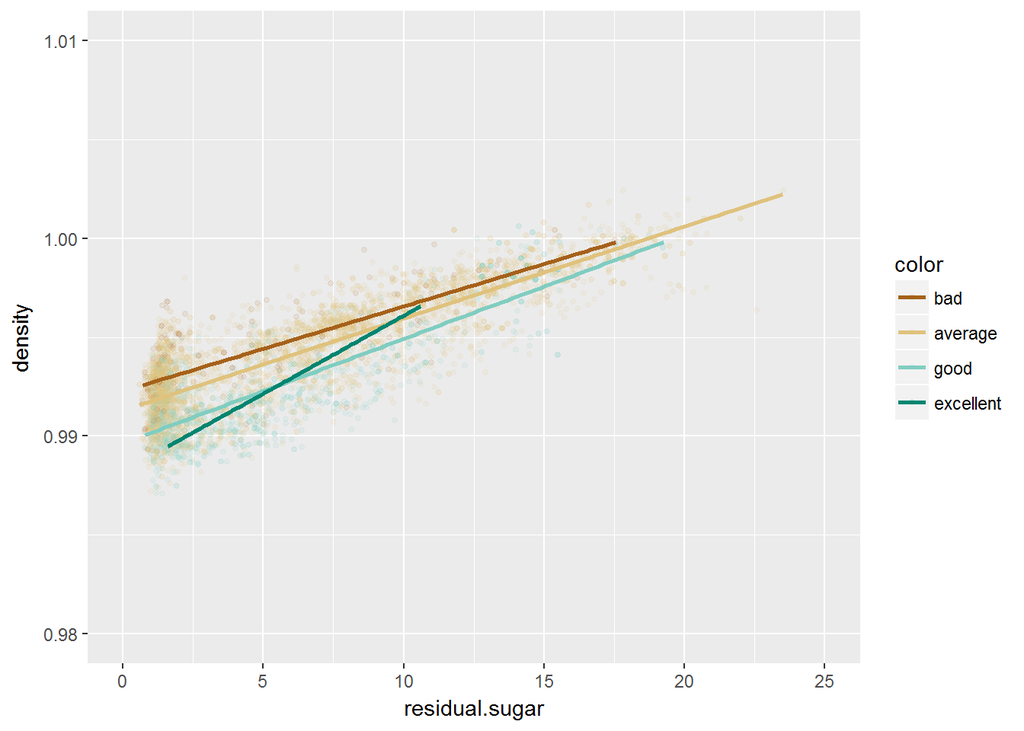

# Multivariate Analysis

### Interesting or surprising interactions between features?

As it was mentioned earlier, the combination of alcohol, density and alcohol affects the quality of wine.

# Final Plots and Summary

### Plot One

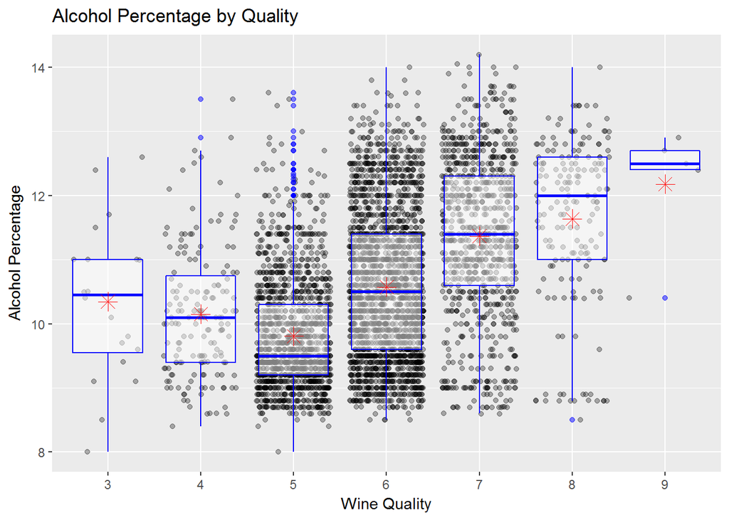

### Plot Two

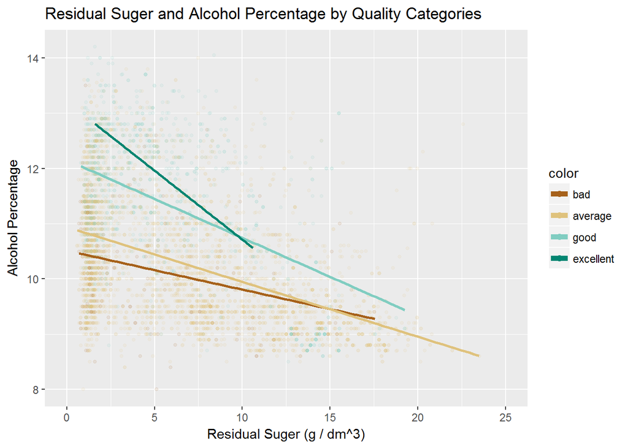

### Description Two

High quality wines have less than 20mg residual.suger. As it is presented in the diagram the less residual.suger and the more alcohol the more chance you have a better quality wine.

### Plot Three

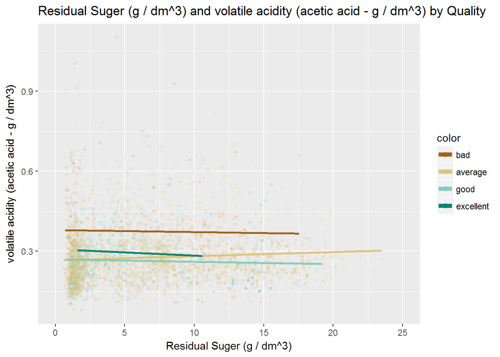

### Description Three

# Reflection

In this project, I analyzed the effect of different variables of white wine on its quality based on the dataset that contained 4,898 observations with 11 variables on the chemical properties. I categorized the quality of wine into 4 groups (bad, average, good, excellent). I found out that good wines tend to have more alcohol and less sugar.

I can’t expand my findings to the other white wine datasets since my sample is not a random dataset from all type of white wines, it’s a sample of wines of a specific region in Portuguese called Vinho Verde. And, there might be a combination of several variables (more than two) would outcome to a perfect that wasn’t investigated in this project.